# Final

Hyun, Heo

2018년 9월 9일

# setting

```r
library(tidyverse)
library(car)
library(boot)
dat <- read.csv("mobility.csv")
apply(is.na(dat), 2, sum)
```

```
##                        ID                      Name
##                         0                         0
##                  Mobility                     State
##                        12                         0
##                Population                     Urban
##                         0                         0
##                     Black                Seg_racial
##                         0                         0
##                Seg_income               Seg_poverty
##                         0                         0
##             Seg_affluence                   Commute
##                         0                         0
##                    Income                      Gini
##                         0                         0
##                   Share01                   Gini_99
##                        32                        32
##              Middle_class            Local_tax_rate
##                        32                         1
##        Local_gov_spending             Progressivity
##                         2                         0
##                      EITC           School_spending
##                         0                        10
##     Student_teacher_ratio               Test_scores
##                        30                        36
##                HS_dropout                  Colleges
##                       148                       157
##                   Tuition                Graduation
##                       161                       160
## Labor_force_participation             Manufacturing
##                         0                         0
##           Chinese_imports             Teenage_labor
##                        19                        32
##              Migration_in             Migration_out
##                        17                        17
##              Foreign_born            Social_capital
##                         0                        19
##                 Religious             Violent_crime
##                         0                        27
##            Single_mothers                  Divorced
##                         0                         0
##                   Married                 Longitude
##                         0                         0
##                  Latitude
##                         0
```

```r
dat$State <- as.factor(dat$State) # factorization
dat$Urban <- as.factor(dat$Urban) # factorization
dat$Violent_crime[is.na(dat$Violent_crime)] <- 0
dat <- dat %>%
  filter(!is.na(Mobility))
```

na가 각 컬럼별로 얼마나 있는지 확인하고, Violent_crime이 NA인 것은 0으로, Mobility가 NA인 것은 제거했습니다.

# 1

## a

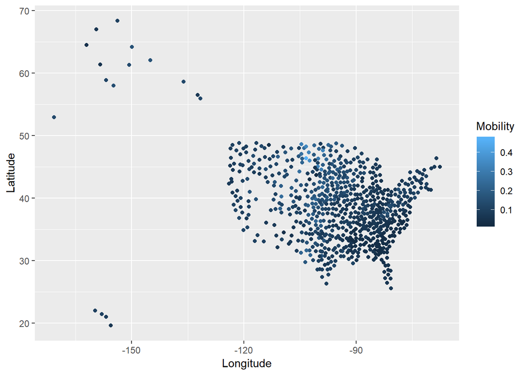

```r
ggplot(dat) + geom_point(aes(x = Longitude, y = Latitude, color = Mobility)) +
  scale_color_gradient()
```

## b

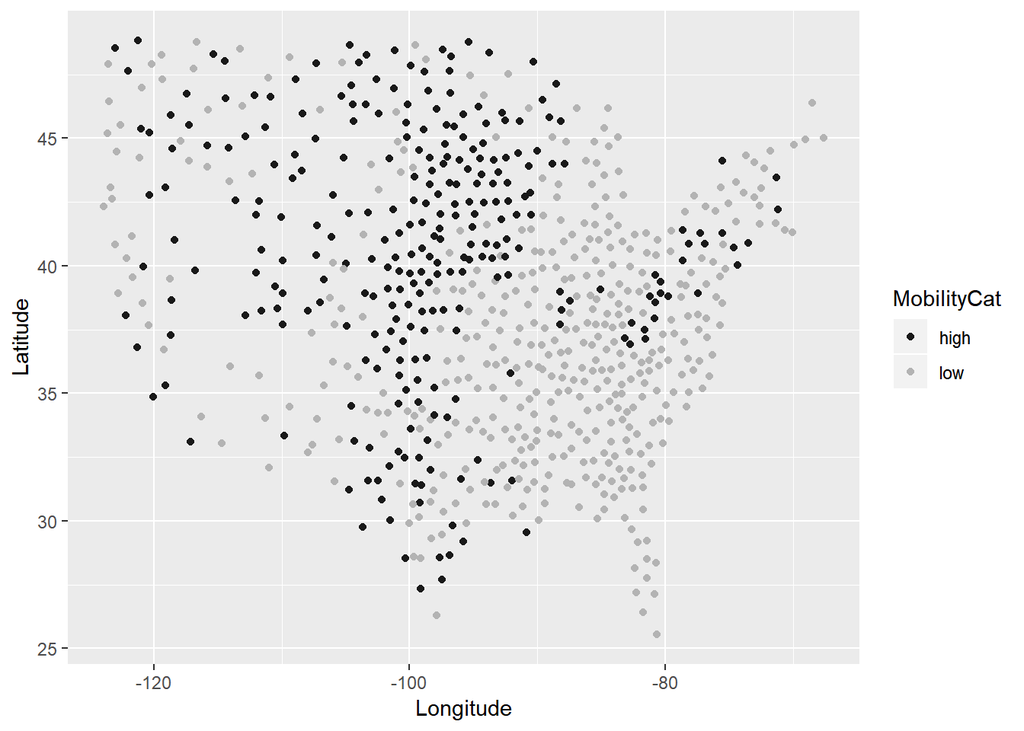

```r
dat %>%
  mutate(MobilityCat = ifelse(Mobility > 0.1, "high", "low")) %>%
  filter(State != "HI", State != "AK") %>%
  ggplot() + geom_point(aes(x = Longitude, y = Latitude, color = MobilityCat))+
  scale_color_grey(start=0.1, end = 0.7)
```

경향성이 좀 더 잘 보인다. 대체적으로 서부가 더 이동성 높다.

# 2

## a : Population

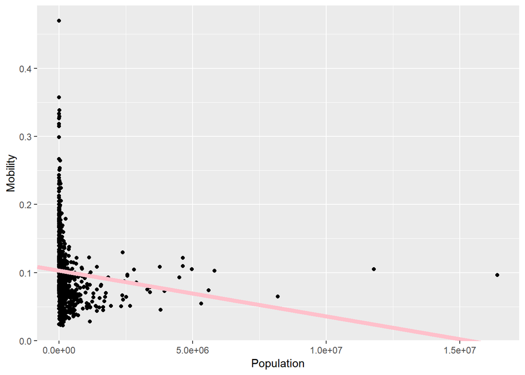

```r
lm.fit <- lm(Mobility~Population, data=dat)
ggplot(dat) + geom_point(aes(x=Population, y=Mobility)) +
  geom_abline(intercept = lm.fit$coefficients[1], slope = lm.fit$coefficients[2], color = "pink", size = 2)
```

```r
lm.fit$coefficients # need log scale
```

```
##   (Intercept)    Population
##  1.030221e-01 -6.732228e-09
```

로그 스케일 적용 등의 변형이 필요해 보인다.

## b : Mean household income per capita

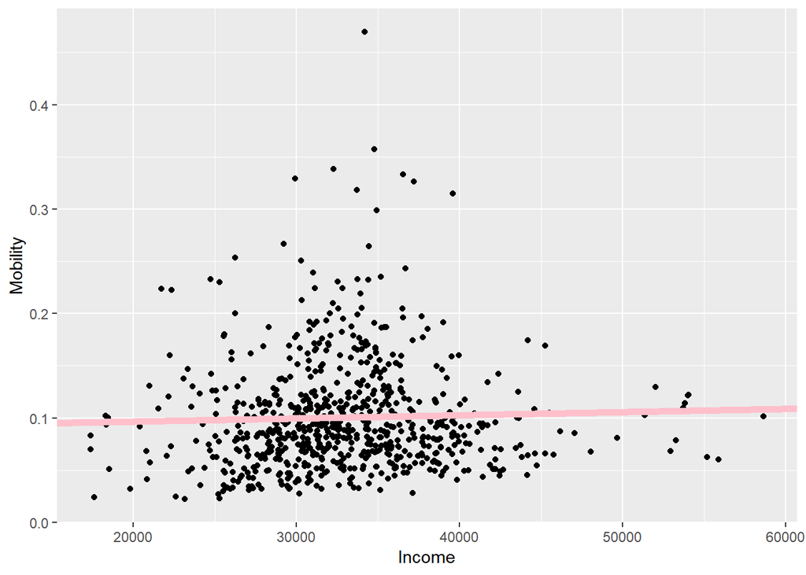

```r
lm.fit <- lm(Mobility~Income, data=dat)
ggplot(dat) + geom_point(aes(x=Income, y=Mobility)) +
  geom_abline(intercept = lm.fit$coefficients[1], slope = lm.fit$coefficients[2], color = "pink", size = 2)
```

```r
lm.fit$coefficients
```

```
##  (Intercept)       Income
## 9.024633e-02 3.094097e-07
```

## c : Racial segregation

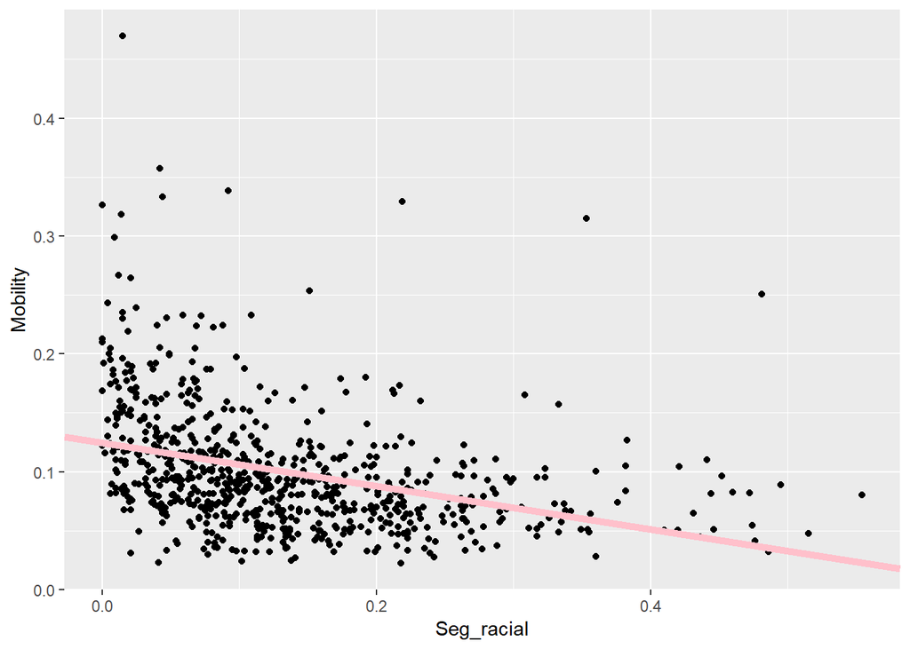

```r
lm.fit <- lm(Mobility~Seg_racial, data=dat)
ggplot(dat) + geom_point(aes(x=Seg_racial, y=Mobility)) +
  geom_abline(intercept = lm.fit$coefficients[1], slope = lm.fit$coefficients[2], color = "pink", size = 2)
```

```r
lm.fit$coefficients
```

```
## (Intercept)  Seg_racial
##   0.1246090  -0.1835019
```

## d : Income share of the top 1%

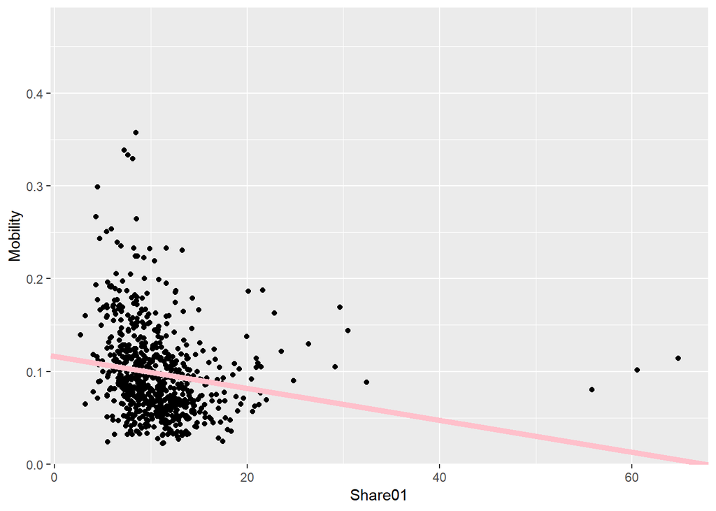

```r
lm.fit <- lm(Mobility~Share01, data=dat)
ggplot(dat) + geom_point(aes(x=Share01, y=Mobility)) +
  geom_abline(intercept = lm.fit$coefficients[1], slope = lm.fit$coefficients[2], color = "pink", size = 2)
```

```r
lm.fit$coefficients # need log scale or remove outlier
```

```
##  (Intercept)      Share01
##  0.116250913 -0.001718199
```

로그 스케일 변화나 아웃라이어 제거 등을 할 필요가 있다.

## e : Mean school expenditures per pupil

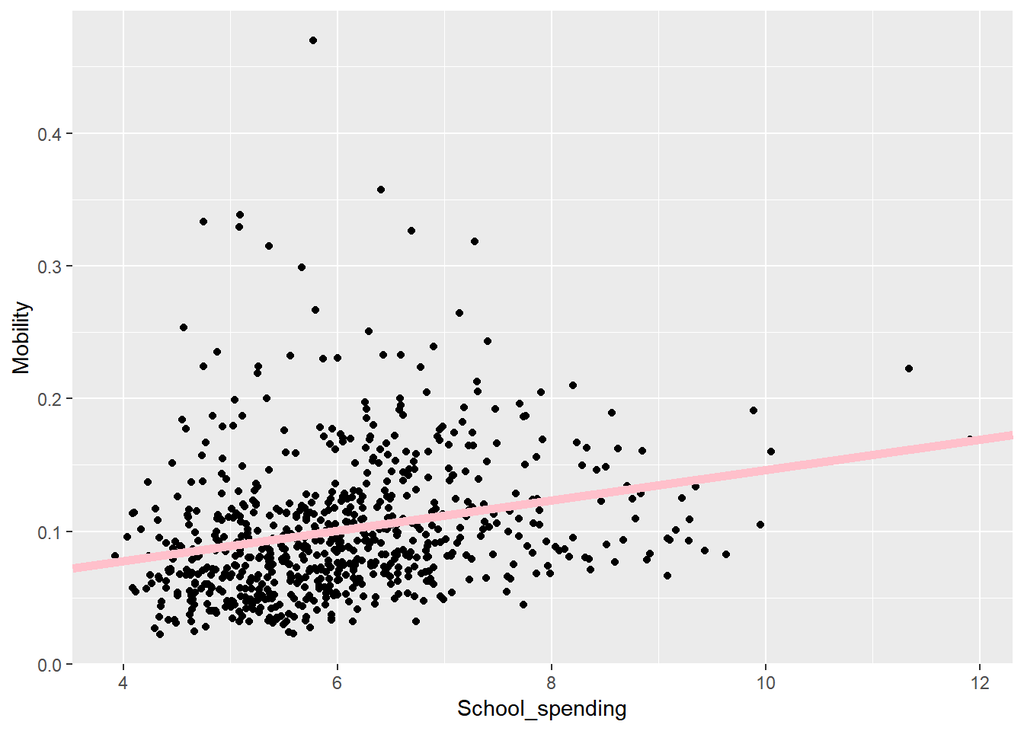

```r
lm.fit <- lm(Mobility~School_spending, data=dat)
ggplot(dat) + geom_point(aes(x=School_spending, y=Mobility)) +
  geom_abline(intercept = lm.fit$coefficients[1], slope = lm.fit$coefficients[2], color = "pink", size = 2)
```

```r
lm.fit$coefficients
```

```
##     (Intercept) School_spending
##      0.03167886      0.01146429
```

## f : Violent crime rate

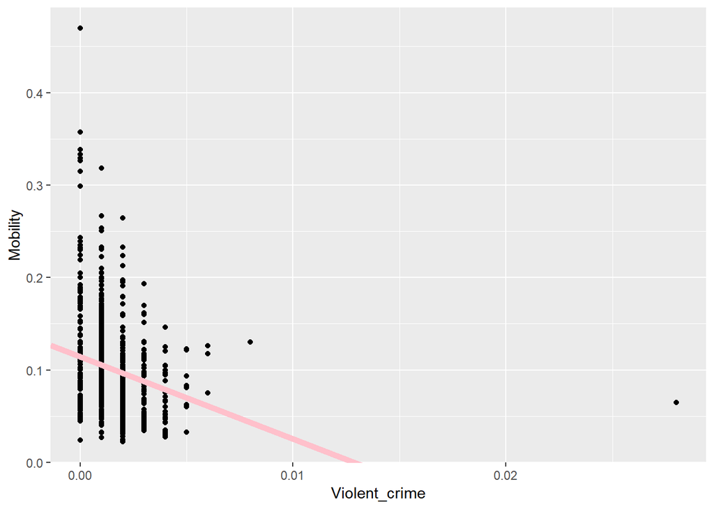

```r
lm.fit <- lm(Mobility~Violent_crime, data=dat)
ggplot(dat) + geom_point(aes(x=Violent_crime, y=Mobility)) +
  geom_abline(intercept = lm.fit$coefficients[1], slope = lm.fit$coefficients[2], color = "pink", size = 2)
```

```r
lm.fit$coefficients # discrete
```

```
##   (Intercept) Violent_crime
##     0.1141647    -8.8964011
```

Violent_crime이 이산형으로 나오는데, 그것에 대한 이유는 알 수 없지만, 이산형이기 때문에 회귀직선이 명확하지 않다.

## g : Fraction of workers with short commutes

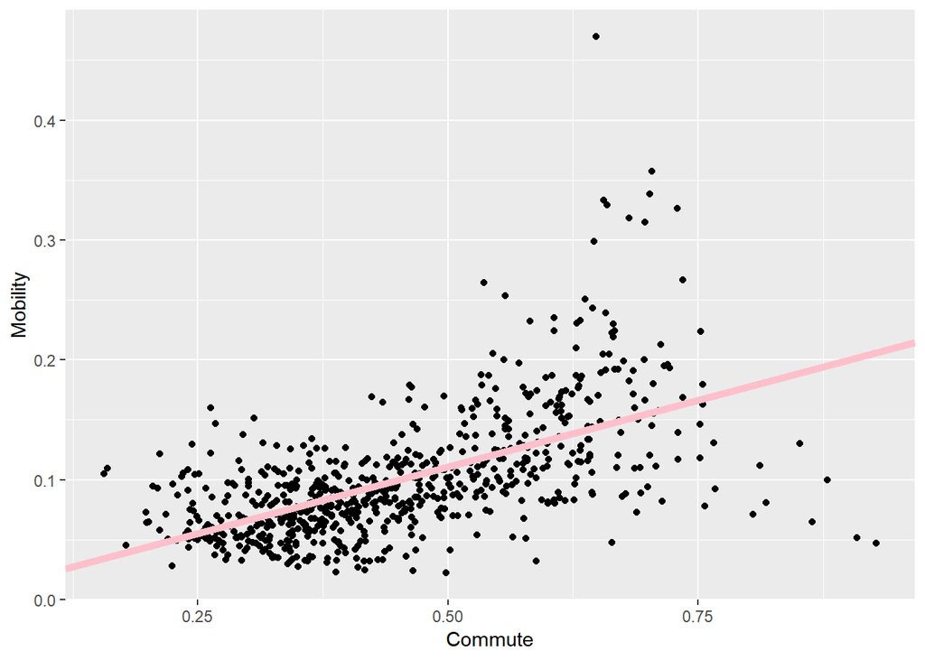

```r
lm.fit <- lm(Mobility~Commute, data=dat)
ggplot(dat) + geom_point(aes(x=Commute, y=Mobility)) +
  geom_abline(intercept = lm.fit$coefficients[1], slope = lm.fit$coefficients[2], color = "pink", size = 2)
```

```r
lm.fit$coefficients
```

```
##   (Intercept)       Commute
## -0.0001972589  0.2218695292
```

# 3

## a

```r
lm_appro <- lm(Mobility~.-ID-Name-State-Longitude-Latitude-HS_dropout-Student_teacher_ratio
               , data=dat) # not appropriate or NA
# summary(lm_appro)
coeffs <- summary(lm_appro)$coef[,1:2]
coeffs
```

```
##                                Estimate   Std. Error
## (Intercept)                2.169103e-01 6.197069e-02
## Population                 3.323904e-09 1.977856e-09
## Urban1                     1.107316e-03 3.355312e-03
## Black                      7.133101e-02 2.333282e-02
## Seg_racial                -5.444195e-02 1.550292e-02
## Seg_income                 9.774554e-01 8.050668e-01
## Seg_poverty               -7.585008e-01 4.284312e-01
## Seg_affluence             -3.227451e-01 4.033419e-01
## Commute                    8.145290e-02 2.228163e-02
## Income                     1.486239e-07 4.698681e-07
## Gini                       2.486803e+00 2.773427e+00
## Share01                   -2.510551e-02 2.774133e-02
## Gini_99                   -2.610050e+00 2.773206e+00
## Middle_class               9.398982e-02 3.941405e-02
## Local_tax_rate             8.301653e-02 2.233760e-01
## Local_gov_spending        -1.022199e-06 2.538326e-06
## Progressivity              5.746026e-03 1.078929e-03
## EITC                      -4.115698e-04 3.958598e-04
## School_spending            8.205645e-04 1.697315e-03
## Test_scores                3.866727e-04 2.529090e-04
## Colleges                  -1.102372e-01 6.871627e-02
## Tuition                    2.723860e-08 3.780511e-07
## Graduation                -2.445258e-02 1.156141e-02
## Labor_force_participation -4.668839e-02 3.924076e-02
## Manufacturing             -1.719182e-01 2.384028e-02
## Chinese_imports           -4.159541e-04 5.941356e-04
## Teenage_labor             -1.504754e+00 1.819668e+00
## Migration_in              -1.542940e-01 2.373982e-01
## Migration_out             -5.005429e-01 3.118996e-01
## Foreign_born               6.570068e-02 4.059471e-02
## Social_capital             2.852098e-04 2.180828e-03
## Religious                  5.022946e-02 1.048818e-02
## Violent_crime             -2.421677e+00 1.313992e+00
## Single_mothers            -3.465010e-01 7.936520e-02
## Divorced                  -4.861436e-02 1.248188e-01
## Married                   -9.381968e-02 6.348094e-02
```

## b

ID 변수는 식별을 위해 필요하지만 회귀 등의 방법에 사용하기에는 담고 있는 정보가 무의미해서 사용하지 않는다. 만약 사용한다면 굉장히 잘못된 결과가 나올 것이다.

## c

더 많은 변수를 제거했어야 했다고 생각하지만 stepwise 방식을 쓰지 않고 필요하다고 생각되는 변수를 넣으려고 하니 쉽게 변수를 제거할 수 없었다. 점차적으로 최적화 해나가는 과정이 있을 것이라 생각하고 최소한의 변수만 제거하려고 했다. 이 때 제거한 변수는 b에서 설명한 ID, ID와 비슷한 역할을 하는 Name과 State, 지도를 그릴 때에는 유용하지만 회귀의 독립변수라 할 수 없는 위경도, NA 값이 높은 HS_dropout과 Student_teacher_ratio를 제거했다.

## d

```r
coeffs[c("Population", "Income", "Seg_racial", "Share01", "School_spending", "Violent_crime", "Commute"),]
```

[output not shown]

계수가 변했다. 부호가 바뀐 경우도 있다. 이유는 변수간의 공분산 혹은 공선성이다.

## e

```r
vif_appro <- vif(lm_appro)
vif_appro[vif_appro > 10] # ridge or variable elimination
```

```
##     Seg_income    Seg_poverty  Seg_affluence           Gini        Share01
##      541.51845      130.57276      168.76674    42717.77082    11628.84732
##        Gini_99 Single_mothers
##    22652.91845       15.54245
```

VIF가 10 초과인 7개의 변수가 나왔다. 대부분 10뿐 아니라 100 이상이라는 점에서 다중공선성이 매우 의심된다. 해결책으로는 Ridge regression, PCA 등이 있고 직접 해당 변수들을 제거하는 방법도 있다.

# 4

## b

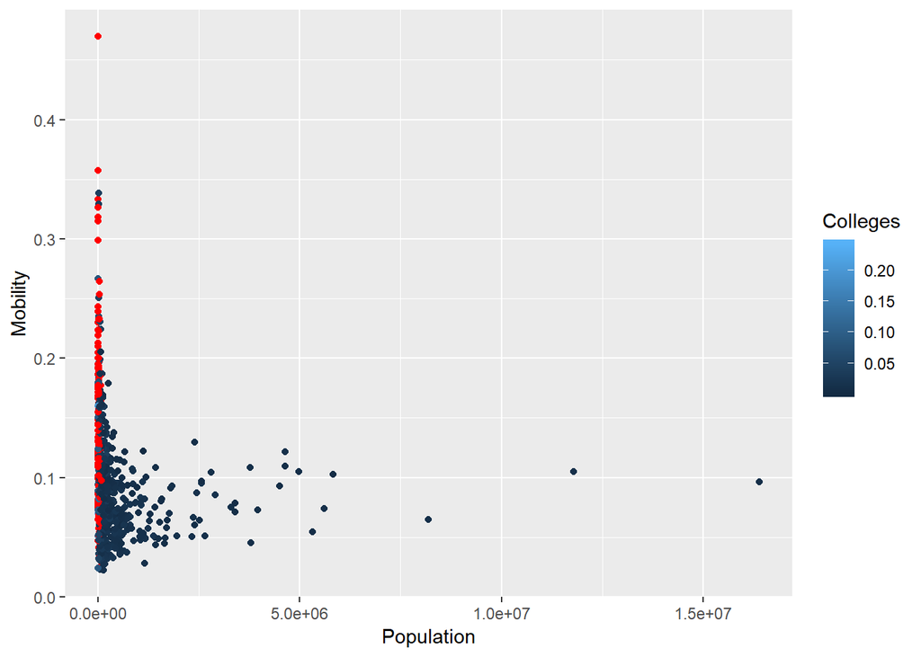

```r
ggplot(dat) + geom_point(aes(x=Population, y=Mobility, color = Colleges)) +
  scale_color_gradient(na.value = "red")
```

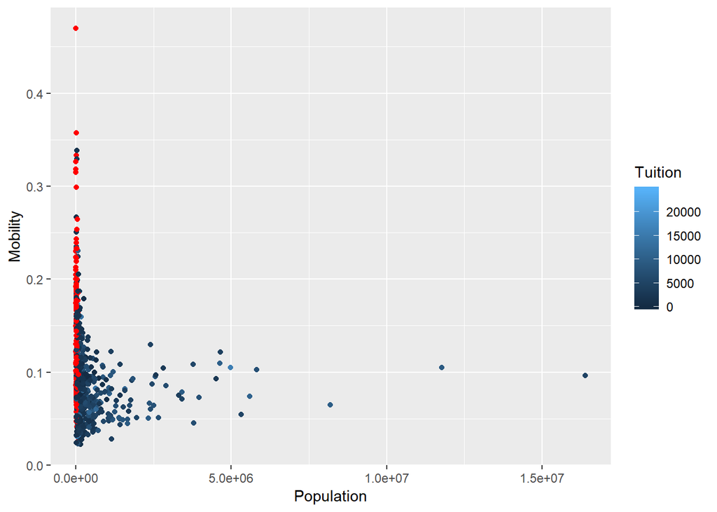

```r
ggplot(dat) + geom_point(aes(x=Population, y=Mobility, color = Tuition)) +
  scale_color_gradient(na.value = "red")
```

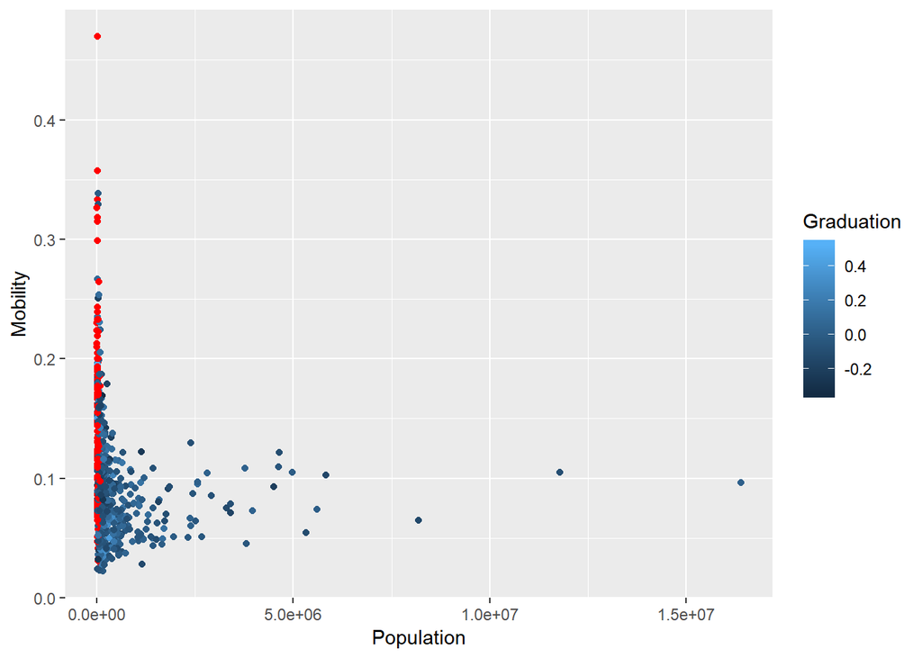

```r
ggplot(dat) + geom_point(aes(x=Population, y=Mobility, color = Graduation)) +
  scale_color_gradient(na.value = "red")
```

인구수가 0에 굉장히 가까울 때 각 값이 결측되어있다. 따라서 결측을 0으로 생각해도 무방하다.

## c

```r
dat[,c("Colleges", "Tuition", "Graduation")][is.na(dat[,c("Colleges", "Tuition", "Graduation")])] <- 0
dat <- dat %>%
  mutate(HE = ifelse(Colleges == 0 & Tuition == 0 & Graduation ==0, 0, 1))
```

# 5

```r
dat <- dat %>%
  mutate(logMobil=log(Mobility))
flm.fit <- lm(logMobil~Population+Seg_poverty+Commute+Gini+Manufacturing+
                Religious+Violent_crime+Single_mothers+Progressivity,
              data=dat)
# summary(flm.fit)
fcoeff <- summary(flm.fit)$coef
fcoeff[,1:2]
```

```
##                     Estimate   Std. Error
## (Intercept)    -1.281799e+00 1.014244e-01
## Population      3.377413e-08 9.777815e-09
## Seg_poverty    -1.332549e+00 4.100652e-01
## Commute         4.744302e-01 1.025020e-01
## Gini           -5.821006e-01 1.480652e-01
## Manufacturing  -1.450676e+00 1.209517e-01
## Religious       3.369025e-01 5.742177e-02
## Violent_crime  -1.518066e+01 6.105944e+00
## Single_mothers -5.252460e+00 2.114044e-01
## Progressivity   4.395560e-02 5.906855e-03
```

저는 Mobility 변수를 log화 한 변수를 새로 만들어주었습니다. 설명변수는 되도록 NA가 없는 변수 위주로 활용했습니다. 여러 값을 넣었다 빼면서 다중공선성이 크지 않으면서 유의미한 변수들을 선택했습니다.

# 6

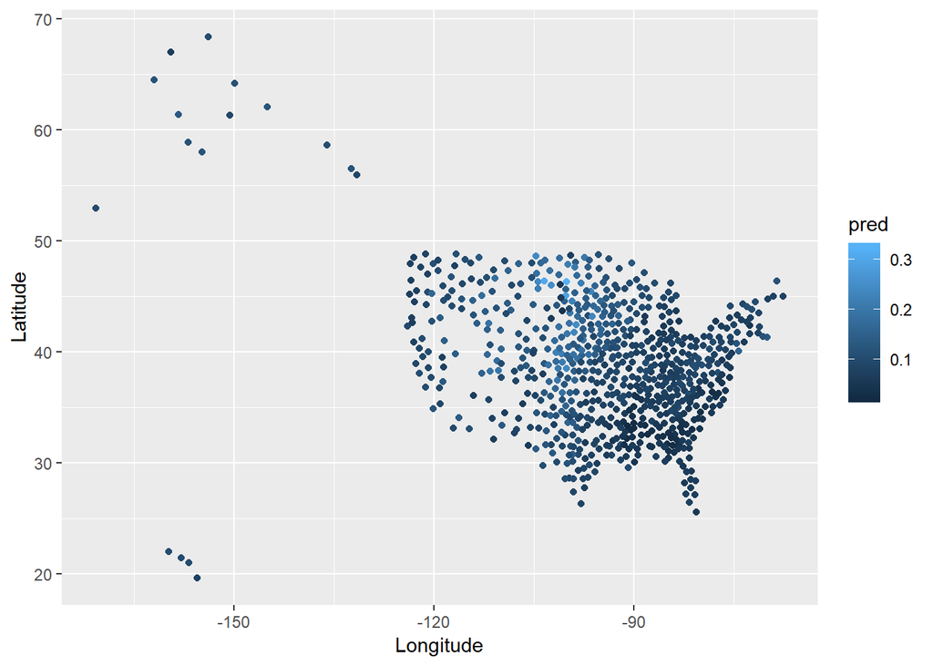

```r
dat$logpred <- predict(flm.fit)
dat$pred <- exp(dat$logpred)
ggplot(dat) + geom_point(aes(x = Longitude, y = Latitude, color = pred)) +
  scale_color_gradient()
```

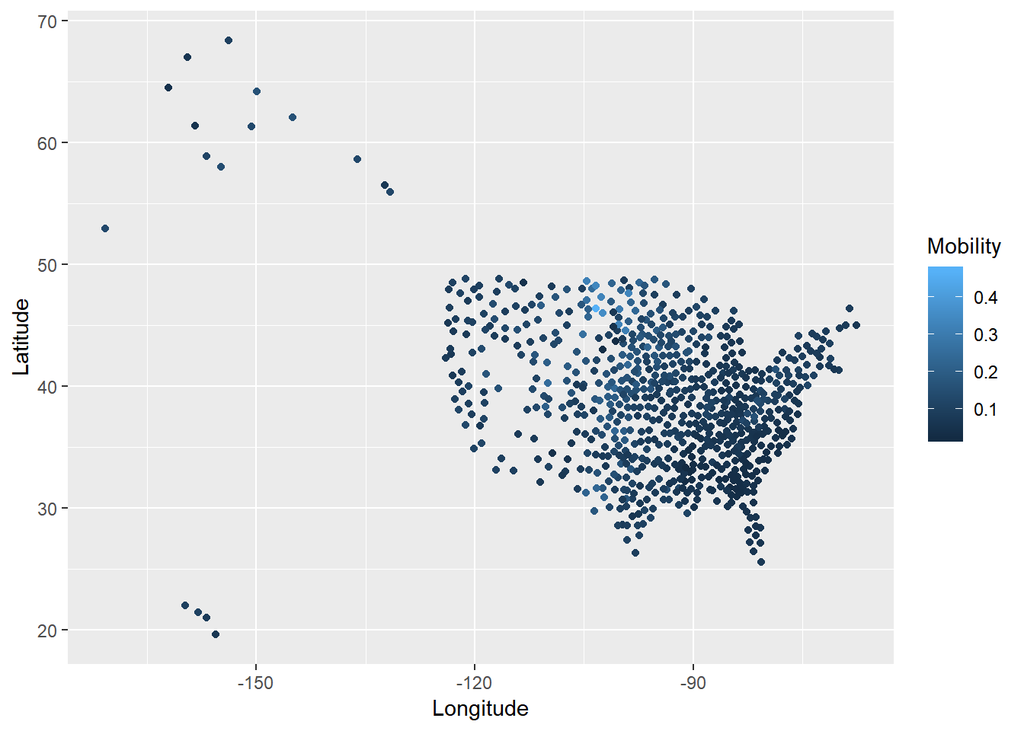

```r
ggplot(dat) + geom_point(aes(x = Longitude, y = Latitude, color = Mobility)) +
  scale_color_gradient()
```

먼저 나온 그림이 예측에 의한 것이고, 나중에 나온 그림이 실제 값을 나타냅니다. 비슷하게 나타나는 것을 보아 어느정도 잘 예측한 것으로 생각됩니다.

# 7

## a

```r
Pitts <- dat %>%
  filter(State == "PA")

Pitts %>%
  select(Mobility, pred)
```

```
##      Mobility       pred
## 1  0.11312765 0.10381128
## 2  0.10237691 0.09989856
## 3  0.09514869 0.08194505
## 4  0.07516681 0.07099230
## 5  0.08709458 0.08128298
## 6  0.16298343 0.08677102
## 7  0.11136677 0.08862669
## 8  0.10745317 0.08988621
## 9  0.10162095 0.07517383
## 10 0.08263150 0.08114447
## 11 0.09630954 0.08462066
## 12 0.07926829 0.08430899
## 13 0.07401167 0.06779892
```

## b

```r
bind_cols(double = Pitts$pred * exp(fcoeff["Violent_crime",1]*Pitts$Violent_crime),
          halve = Pitts$pred / exp(fcoeff["Violent_crime",1]*Pitts$Violent_crime/2))
```

```
## # A tibble: 13 x 2
##    double  halve
##     <dbl>  <dbl>
##  1 0.102  0.105
##  2 0.0984 0.101
##  3 0.0795 0.0832
##  4 0.0699 0.0715
##  5 0.0789 0.0825
##  6 0.0855 0.0874
##  7 0.0860 0.0900
##  8 0.0885 0.0906
##  9 0.0740 0.0757
## 10 0.0799 0.0818
## 11 0.0821 0.0859
## 12 0.0830 0.0850
## 13 0.0648 0.0694
```

## c

```r
exp(predict(flm.fit, Pitts[,names(flm.fit$coefficients)[-1]], level=0.95, interval="confidence"))
```

```
##           fit        lwr        upr
## 1  0.10381128 0.10038009 0.10735974
## 2  0.09989856 0.09696987 0.10291570
## 3  0.08194505 0.07817683 0.08589490
## 4  0.07099230 0.06880999 0.07324381
## 5  0.08128298 0.07780142 0.08492033
## 6  0.08677102 0.08062886 0.09338108
## 7  0.08862669 0.08579679 0.09154992
## 8  0.08988621 0.08744893 0.09239142
## 9  0.07517383 0.07295024 0.07746520
## 10 0.08114447 0.07822321 0.08417483
## 11 0.08462066 0.08124396 0.08813769
## 12 0.08430899 0.08146315 0.08725424
## 13 0.06779892 0.06207572 0.07404978
```

## d

```r
exp(predict(flm.fit, Pitts[,names(flm.fit$coefficients)[-1]], level=0.95, interval="prediction"))
```

```
##           fit        lwr       upr
## 1  0.10381128 0.06657600 0.1618719
## 2  0.09989856 0.06408433 0.1557280
## 3  0.08194505 0.05248867 0.1279322
## 4  0.07099230 0.04553655 0.1106783
## 5  0.08128298 0.05208211 0.1268559
## 6  0.08677102 0.05538301 0.1359480
## 7  0.08862669 0.05684276 0.1381828
## 8  0.08988621 0.05766990 0.1400996
## 9  0.07517383 0.04822269 0.1171877
## 10 0.08114447 0.05202681 0.1265583
## 11 0.08462066 0.05423646 0.1320266
## 12 0.08430899 0.05406583 0.1314694
## 13 0.06779892 0.04315918 0.1065056
```

confidence interval은 주어진 데이터를 이용해서 각 데이터 포인트에서 모수의 값을 추정할 때 95%의 확률로 있을 구간을 정하는 것이고, prediction interval은 모수가 아니라 후에 들어올 수 있는 값의 범위를 95%의 확률로 정하는 것이기 때문에 목적이 다르고, 이런 이유로 prediction interval이 범위가 더 넓다.

# 8

## a

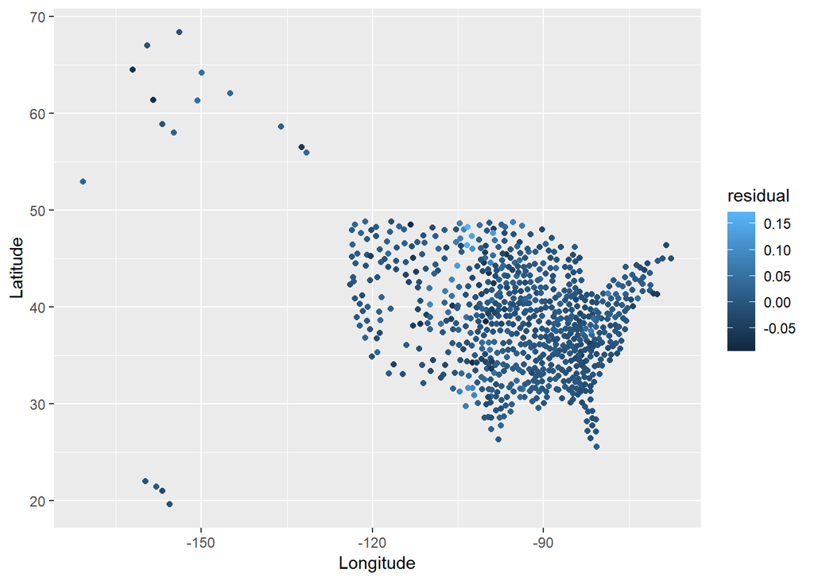

```r
dat <- dat %>%
  mutate(residual = Mobility - pred,
         logres = logMobil - logpred)

g <- ggplot(dat) + geom_point(aes(x = Longitude, y = Latitude, color = residual))
g
```

## b

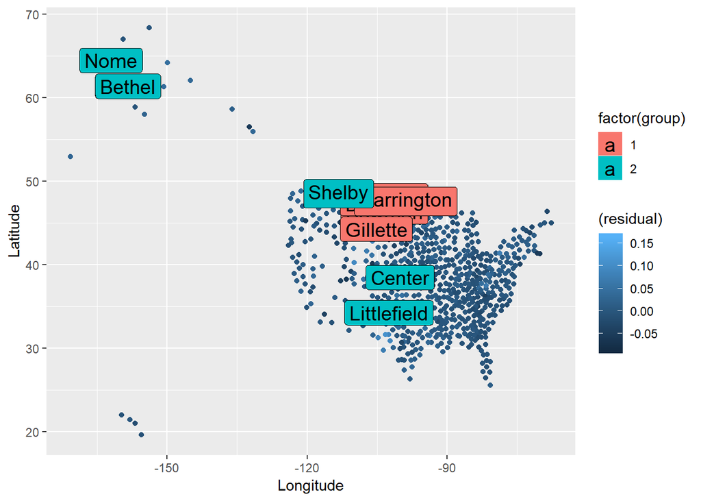

```r
top5 <- dat %>%
  arrange(desc(residual)) %>%
  head(5) %>%
  mutate(group = 1)

bottom5 <- dat %>%
  arrange(residual) %>%
  head(5) %>%
  mutate(group = 2)

tb5 <- bind_rows(top5, bottom5)
g +
  geom_label(data=tb5, aes(x = Longitude, y = Latitude, label=Name, fill = factor(group)), size = 5, parse = TRUE)
```

# 9

## a

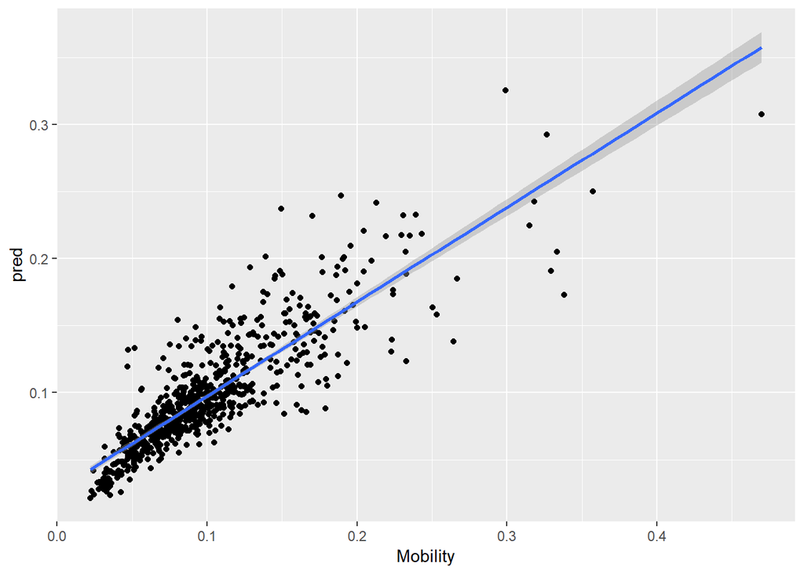

```r
ggplot(dat, aes(x = Mobility, y = pred)) + geom_point() + geom_smooth(method = "lm")
```

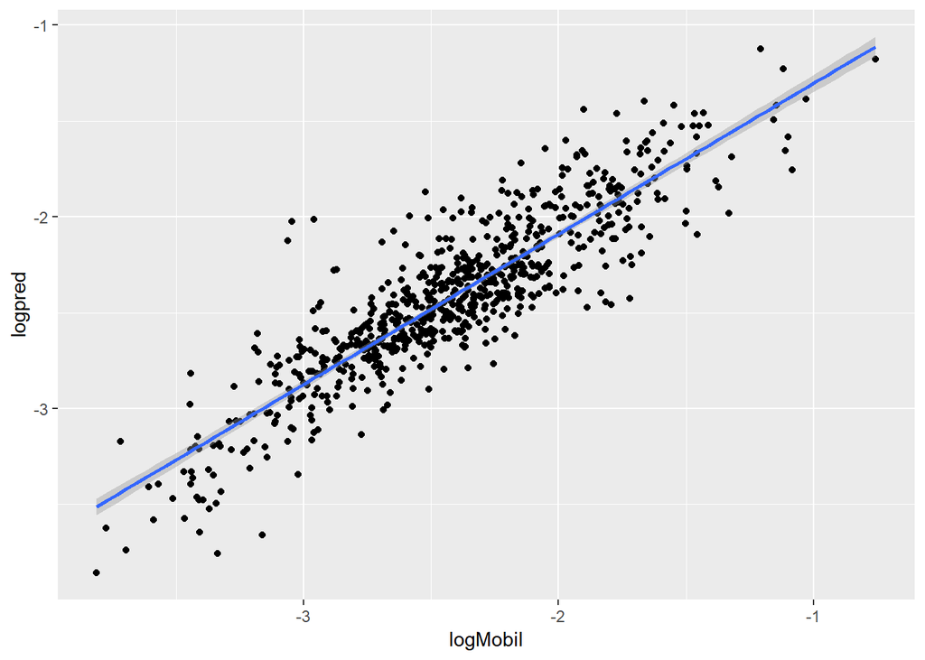

```r
ggplot(dat, aes(x = logMobil, y = logpred)) + geom_point() + geom_smooth(method = "lm")
```

첫번째 그림은 x,y 모두 로그화하지 않은 그림이고 두번째 그림은 로그화 한 그림이다. 로그화 한 경우 선형의 관계가 있음이 확실하다. 즉 잘 예측했다.

## b

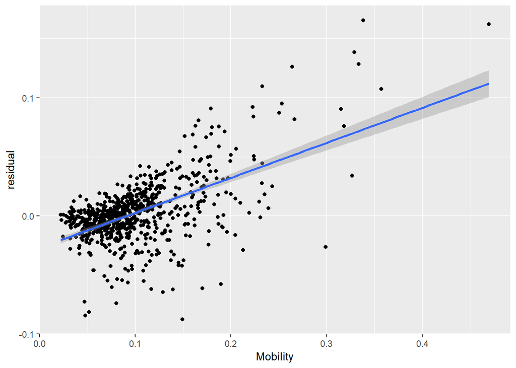

```r
ggplot(dat, aes(x = Mobility, y = residual)) + geom_point() + geom_smooth(method = "lm")
```

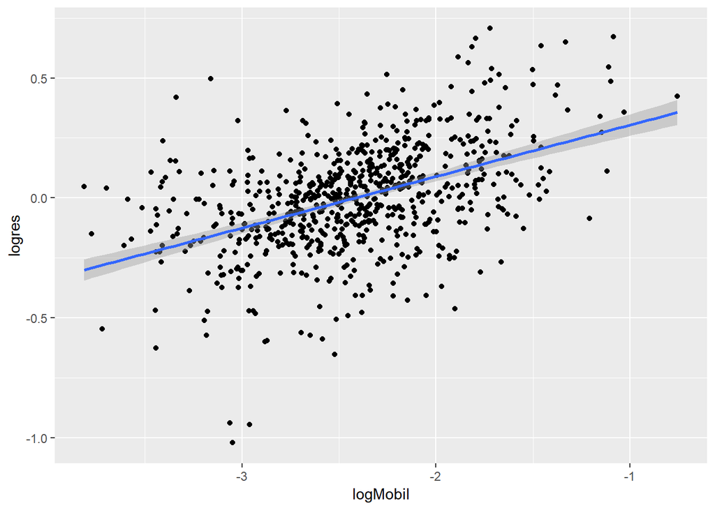

```r
ggplot(dat, aes(x = logMobil, y = logres)) + geom_point() + geom_smooth(method = "lm")
```

첫번째 그림은 x,y 모두 로그화하지 않은 그림이고 두번째 그림은 로그화 한 그림이다. 로그화 한 경우 약간의 경향성은 남아있지만 비교적 관계가 없다. 잔차가 특정 구간에서 다르지 않게 모델링을 잘 했다고 볼 수 있다.

# 10

## a

```r
mmdat <- dat[,c("Middle_class", "Mobility")]
mmdat <- mmdat %>% filter(!is.na(Middle_class))
nlm.fit <- lm(Mobility~Middle_class, data = mmdat)
summary(nlm.fit)
```

```
##
## Call:
## lm(formula = Mobility ~ Middle_class, data = mmdat)
##
## Residuals:
##       Min        1Q    Median        3Q       Max
## -0.077571 -0.026298 -0.009883  0.017227  0.215977
##
## Coefficients:
##              Estimate Std. Error t value Pr(>|t|)
## (Intercept)  -0.09698    0.01040  -9.328   <2e-16 ***
## Middle_class  0.35385    0.01871  18.908   <2e-16 ***
## ---
## Signif. codes:  0 '***' 0.001 '**' 0.01 '*' 0.05 '.' 0.1 ' ' 1
##
## Residual standard error: 0.03916 on 707 degrees of freedom
## Multiple R-squared:  0.3358, Adjusted R-squared:  0.3349
## F-statistic: 357.5 on 1 and 707 DF,  p-value: < 2.2e-16
```

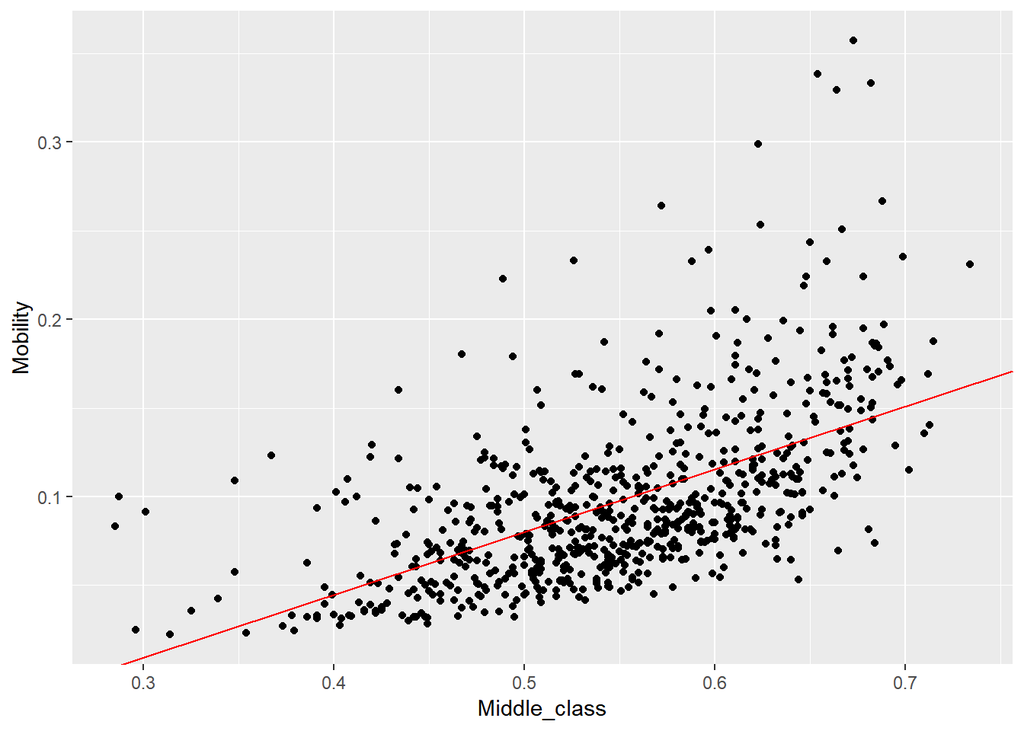

```r
ggplot(mmdat, aes(Middle_class, Mobility)) + geom_point() +
  geom_abline(intercept = nlm.fit$coefficients[1], slope = nlm.fit$coefficients[2], color = "red")
```

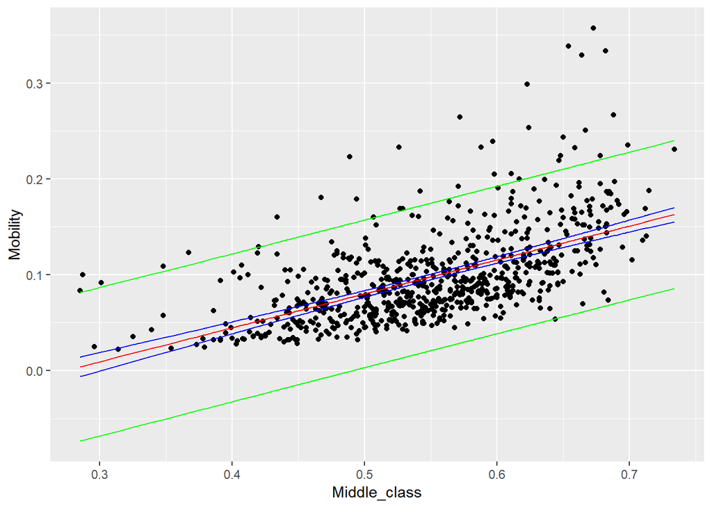

```r
interval_conf <- predict(nlm.fit, interval = "confidence")
interval_pred <- predict(nlm.fit, interval = "prediction")
mmdatinter <- bind_cols(mmdat, as.data.frame(interval_conf), pred_lwr = interval_pred[,2], pred_upr = interval_pred[,3])
ggplot(mmdatinter, aes(Middle_class, Mobility)) + geom_point() +
  geom_line(aes(y=fit), color = "red") +
  geom_line(aes(y=upr), color = "blue") +
  geom_line(aes(y=lwr), color = "blue") +
  geom_line(aes(y=pred_upr), color = "green") +
  geom_line(aes(y=pred_lwr), color = "green")
```

confidence interval은 파란색, prediction interval은 초록색으로 그렸습니다. 그림이 Middle_class가 커지면서 residual의 분산이 커지면서 N(0,2) 꼴은 잘 맞지 않습니다.

## b

```r
boot.conf <- function(data, indices){
  data <- data[indices,]
  lm.fit <- lm(Mobility~Middle_class, data = data)
  interval_conf <- predict(lm.fit, interval = "confidence")
  mean(interval_conf)
}
boot.out <- boot(mmdat, boot.conf, 100)
boot.out
```

```
##
## ORDINARY NONPARAMETRIC BOOTSTRAP
##
##
## Call:
## boot(data = mmdat, statistic = boot.conf, R = 100)
##
##
## Bootstrap Statistics :
##       original       bias    std. error
## t1* 0.09762221 7.851756e-05 0.001762183
```

```r
boot.ci(boot.out, type = c("norm", "perc"))
```

```
## BOOTSTRAP CONFIDENCE INTERVAL CALCULATIONS
## Based on 100 bootstrap replicates
##
## CALL :
## boot.ci(boot.out = boot.out, type = c("norm", "perc"))
##
## Intervals :
## Level      Normal             Percentile
## 95%   ( 0.0941,  0.1010 )   ( 0.0944,  0.1013 )
## Calculations and Intervals on Original Scale
## Some percentile intervals may be unstable
```

```r
boot.pred <- function(data, indices){
  data <- data[indices,]
  lm.fit <- lm(Mobility~Middle_class, data = data)
  interval_pred <- predict(lm.fit, interval = "prediction")
  mean(interval_pred)
}
boot.out <- boot(mmdat, boot.pred, 100)
boot.out
```

```
##
## ORDINARY NONPARAMETRIC BOOTSTRAP
##
##
## Call:
## boot(data = mmdat, statistic = boot.pred, R = 100)
##
##
## Bootstrap Statistics :
##       original        bias    std. error
## t1* 0.09762221 -0.0001234072 0.001771916
```

```r
boot.ci(boot.out, type = c("norm", "perc"))
```

```
## BOOTSTRAP CONFIDENCE INTERVAL CALCULATIONS
## Based on 100 bootstrap replicates
##
## CALL :
## boot.ci(boot.out = boot.out, type = c("norm", "perc"))
##
## Intervals :
## Level      Normal             Percentile
## 95%   ( 0.0943,  0.1012 )   ( 0.0943,  0.1011 )
## Calculations and Intervals on Original Scale
## Some percentile intervals may be unstable
```

먼저 나온 값이 confidence interval을 resampling을 통해 추정한 것이고, 다음 나온 값이 prediction interval을 resampling을 통해 추정한 것이다.

## c

```r
ssfit <- smooth.spline(mmdat$Middle_class, mmdat$Mobility, cv = TRUE)
ssfit
```

```
## Call:
## smooth.spline(x = mmdat$Middle_class, y = mmdat$Mobility, cv = TRUE)
##
## Smoothing Parameter  spar= 0.9962256  lambda= 0.02440121 (13 iterations)
## Equivalent Degrees of Freedom (Df): 5.056275
## Penalized Criterion (RSS): 0.4451398
## PRESS(l.o.o. CV): 0.001433594
```

```r
boot.ss <- function(data, indices){
  data <- data[indices,]
  ssfit <- smooth.spline(data$Middle_class, data$Mobility, df = 5.056275)
  mean(ssfit$y)
}
ssboot <- boot(mmdat, boot.ss, 100)
ssboot
```

```
##
## ORDINARY NONPARAMETRIC BOOTSTRAP
##
##
## Call:
## boot(data = mmdat, statistic = boot.ss, R = 100)
##
##
## Bootstrap Statistics :
##      original        bias    std. error
## t1* 0.0990193 -4.388916e-05   0.0019396
```

```r
boot.ci(ssboot, type = c("norm", "perc"))
```

```
## BOOTSTRAP CONFIDENCE INTERVAL CALCULATIONS
## Based on 100 bootstrap replicates
##
## CALL :
## boot.ci(boot.out = ssboot, type = c("norm", "perc"))
##
## Intervals :
## Level      Normal             Percentile
## 95%   ( 0.0953,  0.1029 )   ( 0.0949,  0.1028 )
## Calculations and Intervals on Original Scale
## Some percentile intervals may be unstable
```

```r
ssci <- boot.ci(ssboot, type = c("perc"))$percent[c(4,5)]
ssci
```

```
## [1] 0.09494894 0.10283993
```

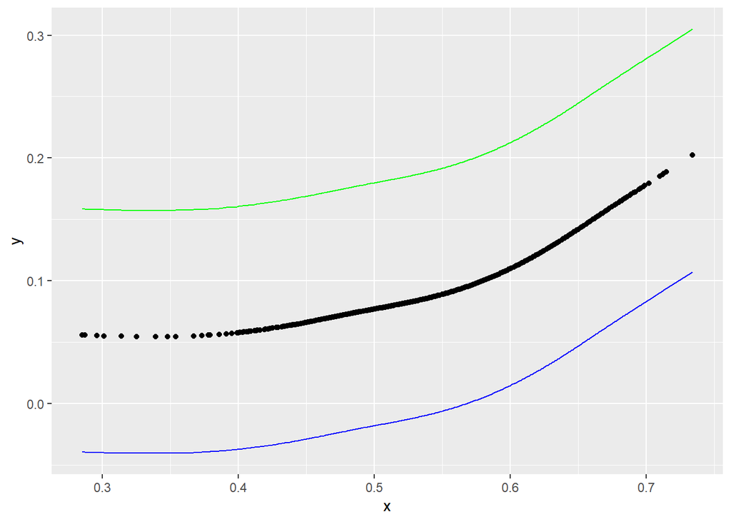

```r
ssdf = bind_cols(x=ssfit$x, y=ssfit$y, lwr = ssfit$y - ssci[1], upr = ssfit$y + ssci[2])

ggplot(ssdf, aes(x, y)) + geom_point() + geom_line(aes(y=lwr), color = "blue") +
  geom_line(aes(y=upr), color = "green")
```

## d

점점 올라가는 형태를 잘 표현할 수 있기 때문에 smoothing이 필요했다.